# MUSA 508 Assignment 4

Leah Shapiro and Palak Agarwal

10/28/2020

# Introduction

The Department of Housing and Community Development (HCD) in Emil City seeks to launch a targeted campaign to encourage homeowners to take advantage of a $10,000 tax credit for home repairs. Typically, only 11% of the eligible homeowners they reach out to take the credit. This analysis attempts to improve the efficiency of HCD’s outreach efforts, minimizing outreach to homeowners who are unlikely to take the credit while maximizing outreach to homeowners who are likely to take the credit.

### Set Up

```r
knitr::opts_chunk$set(echo = TRUE)
knitr::opts_chunk$set(error = FALSE)

options(scipen=10000000)

library(tidyverse)
library(kableExtra)
library(caret)
library(knitr)
library(pscl)
library(plotROC)
library(pROC)
library(lubridate)
library(ggcorrplot)
library(gridExtra)

palette5 <- c("#981FAC","#CB0F8B","#FF006A","#FE4C35","#FE9900")
palette4 <- c("#981FAC","#FF006A","#FE4C35","#FE9900")
palette2 <- c("#981FAC","#FF006A")

house_subsidy <- read.csv("DATA/housingSubsidy.csv")
```

# Data Visualizations

The mean age of those who take the credit is slightly higher than the mean age of eligible homeowners that do not take the credit

The mean number of times homeowners were contacted within one campaign is higher for those who do not take the credit

The mean consumer confidence index and mean consumer price index at the time of the campaign is about the same for those who take the credit and those who do not

NOTE: need to change pdays because 999 represents no previous contact

The mean number of contacts prior to this campaign is higher for those who take the credit than those who do not

The mean amount of money spent annually on repairs is about the same

Not sure how to interpret the plots that aren’t means (categorical variables)

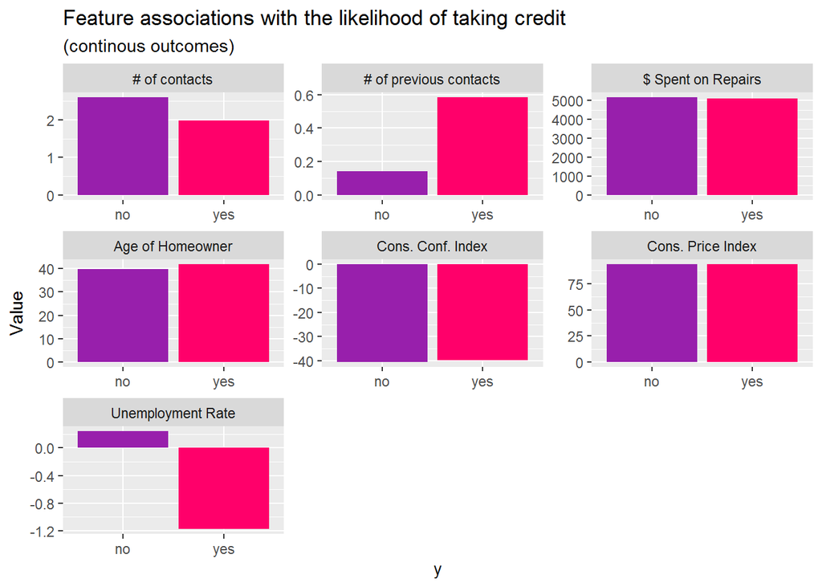

```r
##continuous variables
house_subsidy %>%
  dplyr::select(y,unemploy_rate, spent_on_repairs, age, campaign,
                previous,cons.price.idx,cons.conf.idx) %>%
  rename("Unemployment Rate" = unemploy_rate, "$ Spent on Repairs" = spent_on_repairs, "Age of Homeowner"=age, "# of contacts"=campaign, "# of previous contacts"=previous, "Cons. Price Index"=cons.price.idx, "Cons. Conf. Index"=cons.conf.idx) %>%
  gather(Variable, value, -y) %>%
  ggplot(aes(y, value, fill=y)) +
  geom_bar(position = "dodge", stat = "summary", fun = "mean") +
  facet_wrap(~Variable, scales = "free") +
  scale_fill_manual(values = palette2) +
  labs(x="y", y="Value",
       title = "Feature associations with the likelihood of taking credit",
       subtitle = "(continous outcomes)") +
  theme(legend.position = "none")
```

Interpretation - these plots are not useful because they aren’t normalized and have count associated, not mean

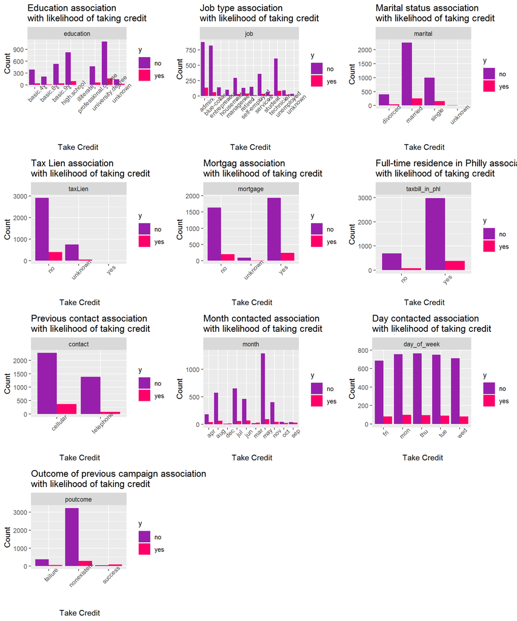

```r
# NOT WORKING
house_subsidy$month <-factor(house_subsidy$month,
                             levels=c("mar","apr","may","jun","jul","aug","sep","oct","nov","dec"))

house_subsidy$day_of_week <-factor(house_subsidy$day_of_week,
                             levels=c("mon","tue","wed","thu","fri"))

## categorical variables
grid.arrange(ncol=3,
house_subsidy %>%
  dplyr::select(y, education) %>%
  gather(Variable, value, -y) %>%
  count(Variable, value, y) %>%
  ggplot(aes(value, n, fill = y)) +
  geom_bar(position = "dodge", stat="identity") +
  facet_wrap(~Variable, scales="free") +
  scale_fill_manual(values = palette2) +
  labs(x="\n Take Credit", y="Count",
       title = "Education association \nwith likelihood of taking credit")+
  theme(axis.text.x = element_text(angle = 45)),


## Jobs
house_subsidy %>%
  dplyr::select(y, job) %>%
  gather(Variable, value, -y) %>%
  count(Variable, value, y) %>%
  ggplot(aes(value, n, fill = y)) +
  geom_bar(position = "dodge", stat="identity") +
  facet_wrap(~Variable, scales="free") +
  scale_fill_manual(values = palette2) +
  labs(x="\n Take Credit", y="Count",
       title = "Job type association \nwith likelihood of taking credit")+
  theme(axis.text.x = element_text(angle = 45)),

## Marital
house_subsidy %>%
  dplyr::select(y, marital) %>%
  gather(Variable, value, -y) %>%
  count(Variable, value, y) %>%
  ggplot(aes(value, n, fill = y)) +
  geom_bar(position = "dodge", stat="identity") +
  facet_wrap(~Variable, scales="free") +
  scale_fill_manual(values = palette2) +
  labs(x="\n Take Credit", y="Count",
       title = "Marital status association \nwith likelihood of taking credit")+
  theme(axis.text.x = element_text(angle = 45)),

## taxLien
house_subsidy %>%
  dplyr::select(y, taxLien) %>%
  gather(Variable, value, -y) %>%
  count(Variable, value, y) %>%
  ggplot(aes(value, n, fill = y)) +
  geom_bar(position = "dodge", stat="identity") +
  facet_wrap(~Variable, scales="free") +
  scale_fill_manual(values = palette2) +
  labs(x="\n Take Credit", y="Count",
       title = "Tax Lien association \nwith likelihood of taking credit")+
  theme(axis.text.x = element_text(angle = 45)),

house_subsidy %>%
  dplyr::select(y, mortgage) %>%
  gather(Variable, value, -y) %>%
  count(Variable, value, y) %>%
  ggplot(aes(value, n, fill = y)) +
  geom_bar(position = "dodge", stat="identity") +
  facet_wrap(~Variable, scales="free") +
  scale_fill_manual(values = palette2) +
  labs(x="\n Take Credit", y="Count",
       title = "Mortgag association \nwith likelihood of taking credit")+
  theme(axis.text.x = element_text(angle = 45)),

house_subsidy %>%
  dplyr::select(y, taxbill_in_phl) %>%
  gather(Variable, value, -y) %>%
  count(Variable, value, y) %>%
  ggplot(aes(value, n, fill = y)) +
  geom_bar(position = "dodge", stat="identity") +
  facet_wrap(~Variable, scales="free") +
  scale_fill_manual(values = palette2) +
  labs(x="\n Take Credit", y="Count",
       title = "Full-time residence in Philly association \nwith likelihood of taking credit")+
  theme(axis.text.x = element_text(angle = 45)),

house_subsidy %>%
  dplyr::select(y, contact) %>%
  gather(Variable, value, -y) %>%
  count(Variable, value, y) %>%
  ggplot(aes(value, n, fill = y)) +
  geom_bar(position = "dodge", stat="identity") +
  facet_wrap(~Variable, scales="free") +
  scale_fill_manual(values = palette2) +
  labs(x="\n Take Credit", y="Count",
       title = "Previous contact association \nwith likelihood of taking credit")+
  theme(axis.text.x = element_text(angle = 45)),

# Change order of months
house_subsidy %>%
  dplyr::select(y, month) %>%
  gather(Variable, value, -y) %>%
  count(Variable, value, y) %>%
  ggplot(aes(value, n, fill = y)) +
  geom_bar(position = "dodge", stat="identity") +
  facet_wrap(~Variable, scales="free") +
  scale_fill_manual(values = palette2) +
  labs(x="\n Take Credit", y="Count",
       title = "Month contacted association \nwith likelihood of taking credit")+
  theme(axis.text.x = element_text(angle = 45)),

# Change order of days
house_subsidy %>%
  dplyr::select(y, day_of_week) %>%
  gather(Variable, value, -y) %>%
  count(Variable, value, y) %>%
  ggplot(aes(value, n, fill = y)) +
  geom_bar(position = "dodge", stat="identity") +
  facet_wrap(~Variable, scales="free") +
  scale_fill_manual(values = palette2) +
  labs(x="\n Take Credit", y="Count",
       title = "Day contacted association \nwith likelihood of taking credit")+
  theme(axis.text.x = element_text(angle = 45)),

house_subsidy %>%
  dplyr::select(y, poutcome) %>%
  gather(Variable, value, -y) %>%
  count(Variable, value, y) %>%
  ggplot(aes(value, n, fill = y)) +
  geom_bar(position = "dodge", stat="identity") +
  facet_wrap(~Variable, scales="free") +
  scale_fill_manual(values = palette2) +
  labs(x="\n Take Credit", y="Count",
       title = "Outcome of previous campaign association \nwith likelihood of taking credit")+
  theme(axis.text.x = element_text(angle = 45))
)
```

### Feature Engineering

One paragraph interpreting new features employment status matters more than type of job Seasons may impact when people are thinking about house repairs days of week - beginning/end of week vs. middle of week, when are going to be more receptive to the marketing campaign

Employment status plot weird b/c dummy var Struggling with interpretation of these - ask Matthew?

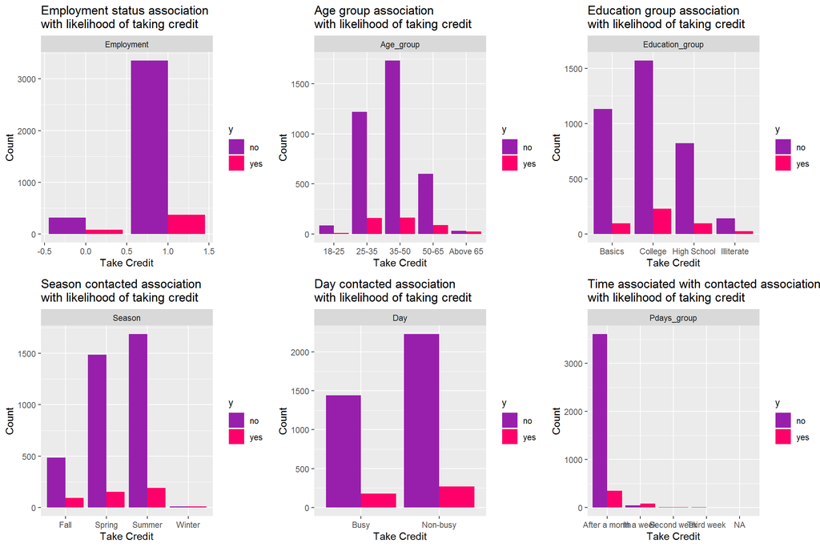

```r
## Data wrangling
### Employment

house_subsidy <-
  house_subsidy %>%
  mutate(Employment = ifelse(house_subsidy$job == "blue-collar"|house_subsidy$job == "services"|house_subsidy$job =="admin."|house_subsidy$job =="entrepreneur"|
                               house_subsidy$job =="self-employed"|house_subsidy$job =="technician"|house_subsidy$job =="management"|
                               house_subsidy$job =="housemaid",1,0))
### Pdays
house_subsidy <-
  house_subsidy %>%
  mutate(Pdays_group = case_when(
    pdays >= 1 & pdays <= 7 ~ "In a week",
    pdays >= 8 & pdays <= 14  ~ "Second week",
    pdays >= 15 & pdays <= 21  ~ "Third week",
    pdays >= 22 & age < 999  ~ "After a month",
    pdays >= 999   ~ "Never contacted"))

### Age
house_subsidy <-
  house_subsidy %>%
  mutate(Age_group = case_when(
    age < 18 ~ "Less than 18",
    age >= 18 & age < 25  ~ "18-25",
    age >= 25 & age < 35  ~ "25-35",
    age >= 35 & age <= 50  ~ "35-50",
    age >= 50 & age < 65   ~ "50-65",
    age >= 65   ~ "Above 65"))

### Education
house_subsidy <-
  house_subsidy %>%
  mutate(Education_group = case_when(
    education == "basic.9y" |education == "basic.6y" | education == "basic.4y" ~ "Basics",
    education == "high.school"  ~ "High School",
    education == "university.degree" |education == "professional.course"  ~ "College",
    education == "unknown" |education == "illiterate"  ~ "Illiterate"))

### Seasons
house_subsidy <-
  house_subsidy %>%
  mutate(Season = case_when(
    month == "dec" |month == "jan" | month == "feb" ~ "Winter",
    month == "mar" |month == "apr" | month == "may" ~ "Spring",
    month == "jun" |month == "jul" | month == "aug" ~ "Summer",
    month == "sep" |month == "oct" | month == "nov" ~ "Fall"))

### Day
house_subsidy <-
  house_subsidy %>%
  mutate(Day = case_when(
    day_of_week == "mon" |day_of_week == "fri" ~ "Busy",
    day_of_week == "tue" |day_of_week == "wed" | day_of_week == "thu" ~ "Non-busy"))


grid.arrange (ncol=3,
house_subsidy %>%
  dplyr::select(y, Employment) %>%
  gather(Variable, value, -y) %>%
  count(Variable, value, y) %>%
  ggplot(aes(value, n, fill = y)) +
  geom_bar(position = "dodge", stat="identity") +
  facet_wrap(~Variable, scales="free") +
  scale_fill_manual(values = palette2) +
  labs(x="Take Credit", y="Count",
       title = "Employment status association \nwith likelihood of taking credit"),

house_subsidy %>%
  dplyr::select(y, Age_group) %>%
  gather(Variable, value, -y) %>%
  count(Variable, value, y) %>%
  ggplot(aes(value, n, fill = y)) +
  geom_bar(position = "dodge", stat="identity") +
  facet_wrap(~Variable, scales="free") +
  scale_fill_manual(values = palette2) +
  labs(x="Take Credit", y="Count",
       title = "Age group association \nwith likelihood of taking credit"),

house_subsidy %>%
  dplyr::select(y, Education_group) %>%
  gather(Variable, value, -y) %>%
  count(Variable, value, y) %>%
  ggplot(aes(value, n, fill = y)) +
  geom_bar(position = "dodge", stat="identity") +
  facet_wrap(~Variable, scales="free") +
  scale_fill_manual(values = palette2) +
  labs(x="Take Credit", y="Count",
       title = "Education group association \nwith likelihood of taking credit"),

house_subsidy %>%
  dplyr::select(y, Season) %>%
  gather(Variable, value, -y) %>%
  count(Variable, value, y) %>%
  ggplot(aes(value, n, fill = y)) +
  geom_bar(position = "dodge", stat="identity") +
  facet_wrap(~Variable, scales="free") +
  scale_fill_manual(values = palette2) +
  labs(x="Take Credit", y="Count",
       title = "Season contacted association \nwith likelihood of taking credit"),

house_subsidy %>%
  dplyr::select(y, Day) %>%
  gather(Variable, value, -y) %>%
  count(Variable, value, y) %>%
  ggplot(aes(value, n, fill = y)) +
  geom_bar(position = "dodge", stat="identity") +
  facet_wrap(~Variable, scales="free") +
  scale_fill_manual(values = palette2) +
  labs(x="Take Credit", y="Count",
       title = "Day contacted association \nwith likelihood of taking credit"),

house_subsidy %>%
  dplyr::select(y, Pdays_group) %>%
  gather(Variable, value, -y) %>%
  count(Variable, value, y) %>%
  ggplot(aes(value, n, fill = y)) +
  geom_bar(position = "dodge", stat="identity") +
  facet_wrap(~Variable, scales="free") +
  scale_fill_manual(values = palette2) +
  labs(x="Take Credit", y="Count",
       title = "Time associated with contacted association \nwith likelihood of taking credit"))
```

## Correlation

This plot shows that none of our numeric variables are strongly correlated with whether or not an eligible homeowner takes the credit.

The plot suggests that some of our numeric variables may be colinear. The unemployment rate at time of contact is strongly positively correlated with the inflation rate at time of contact. The inflation rate at time of contact is also strongly positively correlated with the amount of money spent annually on repairs.

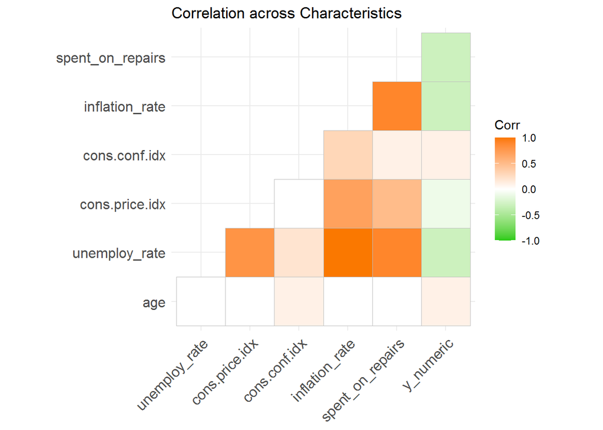

```r
numericVars1 <-
  select_if(house_subsidy, is.numeric) %>% na.omit() %>%
  dplyr::select(age, unemploy_rate, cons.price.idx, cons.conf.idx, inflation_rate, spent_on_repairs,y_numeric)

ggcorrplot(
  round(cor(numericVars1), 1),
  p.mat = cor_pmat(numericVars1),
  colors = c("#25CB10", "white", "#FA7800"),
  type="lower",
  insig = "blank") +
  labs(title = "Correlation across Characteristics")
```

# Compare Models

A very predictive regression would show clustering of 0 (don’t take the credit) around 0 and clustering of 1 (do take the credit) around 1. Neither model shows clustering around 1, indicating that these models have poor sensitivity.

Compare confusion matrices of both regressions

```r
#house_subsidy <- rename(house_subsidy,y.numeric=y_numeric)

set.seed(3456)
trainIndex <- createDataPartition(house_subsidy$y, p = .65,
                                  y = paste(house_subsidy$Education_group,house_subsidy$Age_group,house_subsidy$Season,house_subsidy$Employment,house_subsidy$taxLien),
                                  list = FALSE,
                                  times = 1)
housingTrain <- house_subsidy[ trainIndex,]
housingTest  <- house_subsidy[-trainIndex,]

## Regression
### Kichen Sink Model

kitchensink <- glm(y_numeric ~ .,
                    data=housingTrain %>%
                      dplyr::select(-X, -Season, -Education_group,-Age_group,-Employment, -Day, -y, -Pdays_group),
                    family="binomial" (link="logit"))

summary(kitchensink)
```

```
##
## Call:
## glm(formula = y_numeric ~ ., family = binomial(link = "logit"),
##     data = housingTrain %>% dplyr::select(-X, -Season, -Education_group,
##         -Age_group, -Employment, -Day, -y, -Pdays_group))
##
## Deviance Residuals:
##     Min       1Q   Median       3Q      Max
## -1.8917  -0.4120  -0.3121  -0.2306   3.0631
##
## Coefficients:
##                                  Estimate   Std. Error z value   Pr(>|z|)
## (Intercept)                  -244.0746114  131.7453792  -1.853   0.063936 .
## age                             0.0193943    0.0083034   2.336   0.019506 *
## jobblue-collar                 -0.3677272    0.2691725  -1.366   0.171895
## jobentrepreneur                -0.6526755    0.4674966  -1.396   0.162682
## jobhousemaid                    0.0471368    0.4554009   0.104   0.917561
## jobmanagement                  -0.5410764    0.2938540  -1.841   0.065576 .
## jobretired                     -0.3604107    0.3515830  -1.025   0.305312
## jobself-employed               -0.5725817    0.3976638  -1.440   0.149906
## jobservices                    -0.2735569    0.2848469  -0.960   0.336872
## jobstudent                      0.2026779    0.3924545   0.516   0.605549
## jobtechnician                  -0.3008674    0.2461350  -1.222   0.221569
## jobunemployed                  -0.3936707    0.4402700  -0.894   0.371238
## jobunknown                     -0.5773965    0.7792841  -0.741   0.458735
## maritalmarried                 -0.0830014    0.2352568  -0.353   0.724229
## maritalsingle                   0.2030250    0.2716976   0.747   0.454915
## maritalunknown                  0.2212284    1.1978434   0.185   0.853473
## educationbasic.6y               0.3884405    0.3989009   0.974   0.330167
## educationbasic.9y              -0.0968059    0.3375916  -0.287   0.774300
## educationhigh.school            0.1924139    0.3069856   0.627   0.530800
## educationilliterate           -12.3283877  535.4114490  -0.023   0.981630
## educationprofessional.course    0.1612812    0.3416255   0.472   0.636856
## educationuniversity.degree      0.2155618    0.3114515   0.692   0.488862
## educationunknown                0.2787644    0.3941206   0.707   0.479375
## taxLienunknown                 -0.0081831    0.2149237  -0.038   0.969628
## taxLienyes                     -9.8112270  535.4114692  -0.018   0.985380
## mortgageunknown                 0.0469909    0.5227531   0.090   0.928374
## mortgageyes                    -0.0643194    0.1429662  -0.450   0.652788
## taxbill_in_phlyes               0.1153579    0.1980723   0.582   0.560295
```

[output cut: 19 more lines]

```
## unemploy_rate                  -1.2058334    0.4910437  -2.456   0.014063 *
## cons.price.idx                  1.9887988    0.8646308   2.300   0.021439 *
## cons.conf.idx                   0.0618966    0.0277143   2.233   0.025524 *
## inflation_rate                 -0.1935343    0.4528637  -0.427   0.669120
## spent_on_repairs                0.0115603    0.0107927   1.071   0.284116
## ---
## Signif. codes:  0 '***' 0.001 '**' 0.01 '*' 0.05 '.' 0.1 ' ' 1
##
## (Dispersion parameter for binomial family taken to be 1)
##
##     Null deviance: 1986.7  on 2752  degrees of freedom
## Residual deviance: 1503.1  on 2701  degrees of freedom
## AIC: 1607.1
##
## Number of Fisher Scoring iterations: 12
```

```r
housingModel <- glm(y_numeric ~ .,
                    data=housingTrain %>%
                      dplyr::select(-y,-X, -contact,-month,-day_of_week,-poutcome,-Age_group,
                                 -education, -job),
                    family="binomial" (link="logit"))

summary(housingModel)
```

```
##
## Call:
## glm(formula = y_numeric ~ ., family = binomial(link = "logit"),
##     data = housingTrain %>% dplyr::select(-y, -X, -contact, -month,
##         -day_of_week, -poutcome, -Age_group, -education, -job))
##
## Deviance Residuals:
##     Min       1Q   Median       3Q      Max
## -1.8936  -0.4109  -0.3155  -0.2630   2.6617
##
## Coefficients:
##                              Estimate Std. Error z value Pr(>|z|)
## (Intercept)                 18.125564 147.273733   0.123  0.90205
## age                          0.020234   0.006750   2.998  0.00272 **
## maritalmarried              -0.113155   0.231109  -0.490  0.62440
## maritalsingle                0.331176   0.263750   1.256  0.20925
## maritalunknown               0.183030   1.177920   0.155  0.87652
## taxLienunknown              -0.086723   0.211560  -0.410  0.68186
## taxLienyes                  -9.349369 324.743907  -0.029  0.97703
## mortgageunknown              0.008252   0.493251   0.017  0.98665
## mortgageyes                 -0.020865   0.138893  -0.150  0.88059
## taxbill_in_phlyes            0.109633   0.193758   0.566  0.57151
## campaign                    -0.081747   0.042038  -1.945  0.05183 .
## pdays                        0.003548   0.132482   0.027  0.97863
## previous                    -0.121753   0.128402  -0.948  0.34302
## unemploy_rate               -0.454982   0.236723  -1.922  0.05461 .
## cons.price.idx               0.225658   0.386927   0.583  0.55976
## cons.conf.idx               -0.007774   0.023753  -0.327  0.74346
## inflation_rate               0.231807   0.413255   0.561  0.57485
## spent_on_repairs            -0.009231   0.006847  -1.348  0.17756
## Employment                  -0.029710   0.199726  -0.149  0.88175
## Pdays_groupIn a week         5.208270 131.775042   0.040  0.96847
## Pdays_groupSecond week       5.099827 130.896356   0.039  0.96892
## Pdays_groupThird week        3.449616 130.072071   0.027  0.97884
## Education_groupCollege       0.330627   0.181711   1.820  0.06883 .
## Education_groupHigh School   0.272179   0.203808   1.335  0.18172
## Education_groupIlliterate    0.546941   0.305677   1.789  0.07357 .
## SeasonSpring                 0.026303   0.281548   0.093  0.92557
## SeasonSummer                 0.632355   0.292254   2.164  0.03049 *
## SeasonWinter                 0.720152   0.515625   1.397  0.16252
## DayNon-busy                  0.099609   0.139469   0.714  0.47510
## ---
## Signif. codes:  0 '***' 0.001 '**' 0.01 '*' 0.05 '.' 0.1 ' ' 1
##
## (Dispersion parameter for binomial family taken to be 1)
##
##     Null deviance: 1982.4  on 2751  degrees of freedom
## Residual deviance: 1559.1  on 2723  degrees of freedom
##   (1 observation deleted due to missingness)
## AIC: 1617.1
##
## Number of Fisher Scoring iterations: 11
```

```r
## Adding Coefficients
x <- housingModel$coefficients
exp(x)
```

```
##                (Intercept)                        age
##       74444461.49566254020              1.02044015114
##             maritalmarried              maritalsingle
##              0.89301250259              1.39260441502
##             maritalunknown             taxLienunknown
##              1.20085058697              0.91693069144
##                 taxLienyes            mortgageunknown
##              0.00008702035              1.00828643216
##                mortgageyes          taxbill_in_phlyes
##              0.97935086049              1.11586864764
##                   campaign                      pdays
##              0.92150539287              1.00355437619
##                   previous              unemploy_rate
##              0.88536660388              0.63445949528
##             cons.price.idx              cons.conf.idx
##              1.25314709950              0.99225640622
##             inflation_rate           spent_on_repairs
##              1.26087622107              0.99081135070
##                 Employment       Pdays_groupIn a week
##              0.97072714105            182.77764794803
##     Pdays_groupSecond week      Pdays_groupThird week
##            163.99354737664             31.48830752718
##     Education_groupCollege Education_groupHigh School
##              1.39184098578              1.31282166438
##  Education_groupIlliterate               SeasonSpring
##              1.72795966293              1.02665172639
##               SeasonSummer               SeasonWinter
##              1.88203759170              2.05474468591
##                DayNon-busy
##              1.10473943100
```

```r
## Fit metrics
# pR2(kitchensink)
pR2(housingModel)
```

```
## fitting null model for pseudo-r2
```

```
##          llh      llhNull           G2     McFadden         r2ML         r2CU
## -779.5714022 -991.2194277  423.2960511    0.2135229    0.1425685    0.2776816
```

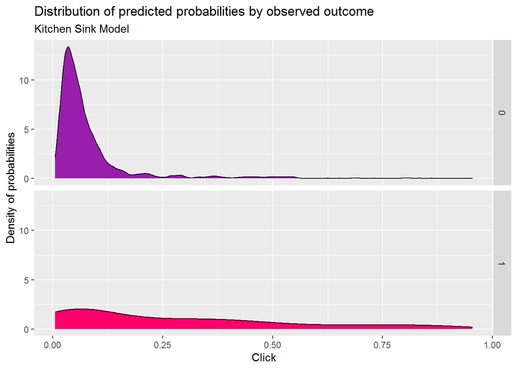

```r
## Prediction
testProbs <- data.frame(Outcome = as.factor(housingTest$y_numeric),
                        Probs = predict(housingModel, housingTest, type= "response"))

testProbskitchensink <- data.frame(Outcome = as.factor(housingTest$y_numeric),
                        Probs = predict(kitchensink, housingTest, type= "response"))

#Here we want more of a hump in the bottom plot around 1 to indicate that the reg is predictive
ggplot(testProbskitchensink, aes(x = Probs, fill = as.factor(Outcome))) +
  geom_density() +
  facet_grid(Outcome ~ .) +
  scale_fill_manual(values = palette2) +
  labs(x = "Click", y = "Density of probabilities",
       title = "Distribution of predicted probabilities by observed outcome",
       subtitle = "Kitchen Sink Model") +
  theme(strip.text.x = element_text(size = 18),
        legend.position = "none")
```

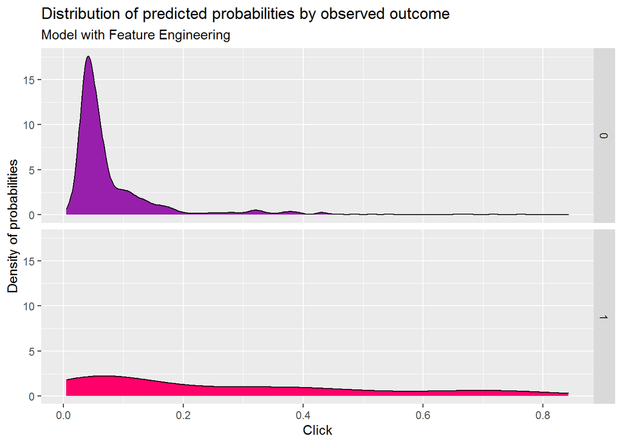

```r
ggplot(testProbs, aes(x = Probs, fill = as.factor(Outcome))) +
  geom_density() +
  facet_grid(Outcome ~ .) +
  scale_fill_manual(values = palette2) +
  labs(x = "Click", y = "Density of probabilities",
       title = "Distribution of predicted probabilities by observed outcome",
       subtitle = "Model with Feature Engineering") +
  theme(strip.text.x = element_text(size = 18),
        legend.position = "none")
```

```r
## Confusion matrix
### Might want to change this threshold, here a probability >50% if being predicted as takes credit
testProbskitchensink <-
  testProbskitchensink %>%
  mutate(predOutcome  = as.factor(ifelse(testProbskitchensink$Probs > 0.5 , 1, 0)))

caret::confusionMatrix(testProbskitchensink$predOutcome, testProbskitchensink$Outcome,
                       positive = "1")
```

```
## Confusion Matrix and Statistics
##
##           Reference
## Prediction    0    1
##          0 1216  102
##          1   21   27
##
##                Accuracy : 0.91
##                  95% CI : (0.8935, 0.9246)
##     No Information Rate : 0.9056
##     P-Value [Acc > NIR] : 0.3087
##
##                   Kappa : 0.2676
##
##  Mcnemar's Test P-Value : 0.0000000000005459
##
##             Sensitivity : 0.20930
##             Specificity : 0.98302
##          Pos Pred Value : 0.56250
##          Neg Pred Value : 0.92261
##              Prevalence : 0.09444
##          Detection Rate : 0.01977
##    Detection Prevalence : 0.03514
##       Balanced Accuracy : 0.59616
##
##        'Positive' Class : 1
##
```

```r
testProbs <-
  testProbs %>%
  mutate(predOutcome  = as.factor(ifelse(testProbs$Probs > 0.5 , 1, 0)))

caret::confusionMatrix(testProbs$predOutcome, testProbs$Outcome,
                       positive = "1")
```

```
## Confusion Matrix and Statistics
##
##           Reference
## Prediction    0    1
##          0 1220  102
##          1   17   26
##
##                Accuracy : 0.9128
##                  95% CI : (0.8966, 0.9273)
##     No Information Rate : 0.9062
##     P-Value [Acc > NIR] : 0.2164
##
##                   Kappa : 0.2696
##
##  Mcnemar's Test P-Value : 0.00000000000001358
##
##             Sensitivity : 0.20312
##             Specificity : 0.98626
##          Pos Pred Value : 0.60465
##          Neg Pred Value : 0.92284
##              Prevalence : 0.09377
##          Detection Rate : 0.01905
##    Detection Prevalence : 0.03150
##       Balanced Accuracy : 0.59469
##
##        'Positive' Class : 1
##
```

## Cross Validation

Compare and interpret two facetted plots of ROC, sensitivity, and specificity Ours is (sometimes) worse :(

```r
## Cross validation
ctrl <- trainControl(method = "cv", number = 100, classProbs=TRUE, summaryFunction=twoClassSummary)

cvFitkitchensink <-train(y ~ .,
               data=house_subsidy %>%
                 dplyr::select(-X, -y_numeric, -Season, -Education_group,-Age_group,-Employment, -Day, -Pdays_group) %>%
                 dplyr::mutate(y = ifelse(y=="yes","c1.yes","c2.no")),
               method="glm", family="binomial",
               metric="ROC", trControl = ctrl)

cvFitkitchensink
```

```
## Generalized Linear Model
##
## 4119 samples
##   19 predictor
##    2 classes: 'c1.yes', 'c2.no'
##
## No pre-processing
## Resampling: Cross-Validated (100 fold)
## Summary of sample sizes: 4078, 4079, 4078, 4079, 4077, 4078, ...
## Resampling results:
##
##   ROC        Sens    Spec
##   0.7702121  0.2265  0.9806306
```

```r
cvFit <- train(y ~ .,
                data=house_subsidy %>%
                  dplyr::select(-y_numeric,-X, -contact,-month,-day_of_week,-poutcome,-Age_group,
                                 -education, -job, -Pdays_group) %>%
                  dplyr::mutate(y = ifelse(y=="yes","c1.yes","c2.no")),
                method="glm", family="binomial",
                metric="ROC", trControl = ctrl)


cvFit
```

```
## Generalized Linear Model
##
## 4119 samples
##   17 predictor
##    2 classes: 'c1.yes', 'c2.no'
##
## No pre-processing
## Resampling: Cross-Validated (100 fold)
## Summary of sample sizes: 4077, 4077, 4077, 4077, 4078, 4079, ...
## Resampling results:
##
##   ROC        Sens   Spec
##   0.7685439  0.218  0.9833634
```

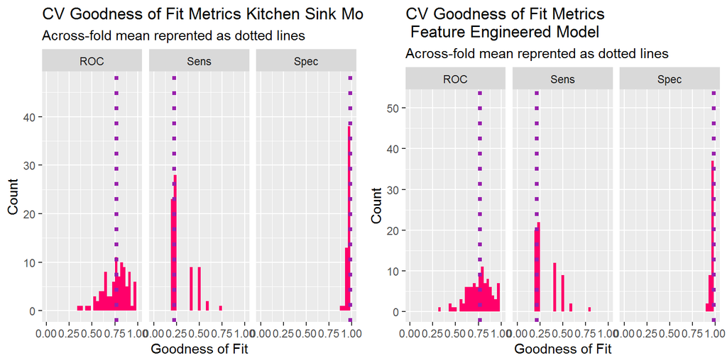

```r
## Goodness metrics
grid.arrange(ncol = 2,

  dplyr::select(cvFitkitchensink$resample, -Resample) %>%
  gather(metric, value) %>%
  left_join(gather(cvFitkitchensink$results[2:4], metric, mean)) %>%
  ggplot(aes(value)) +
  geom_histogram(bins=35, fill = "#FF006A") +
  facet_wrap(~metric) +
  geom_vline(aes(xintercept = mean), colour = "#981FAC", linetype = 3, size = 1.5) +
  scale_x_continuous(limits = c(0, 1)) +
  labs(x="Goodness of Fit", y="Count", title="CV Goodness of Fit Metrics Kitchen Sink Model",
       subtitle = "Across-fold mean reprented as dotted lines"),


  dplyr::select(cvFit$resample, -Resample) %>%
  gather(metric, value) %>%
  left_join(gather(cvFit$results[2:4], metric, mean)) %>%
  ggplot(aes(value)) +
  geom_histogram(bins=35, fill = "#FF006A") +
  facet_wrap(~metric) +
  geom_vline(aes(xintercept = mean), colour = "#981FAC", linetype = 3, size = 1.5) +
  scale_x_continuous(limits = c(0, 1)) +
  labs(x="Goodness of Fit", y="Count", title="CV Goodness of Fit Metrics \n Feature Engineered Model",
       subtitle = "Across-fold mean reprented as dotted lines"))
```

### Receiver Operating Characteristic Curve

Interpret ROC curve for new model Visualizes trade-offs of the model.When increase true positives, also increase false positives, that means HCD will waste money on marketing

add explanation about trade offs for thresholds

explain AUC,100% is overfit, 50% would be coin flip, this indicates that our model predicts reasonably well and is generalizable, this is a goodness of fit metric

```r
## ROC curve
# This us a goodness of fit measure, 1 would be a perfect fit, .5 is a coin toss
auc(testProbs$Outcome, testProbs$Probs)
```

```
## Area under the curve: 0.7219
```

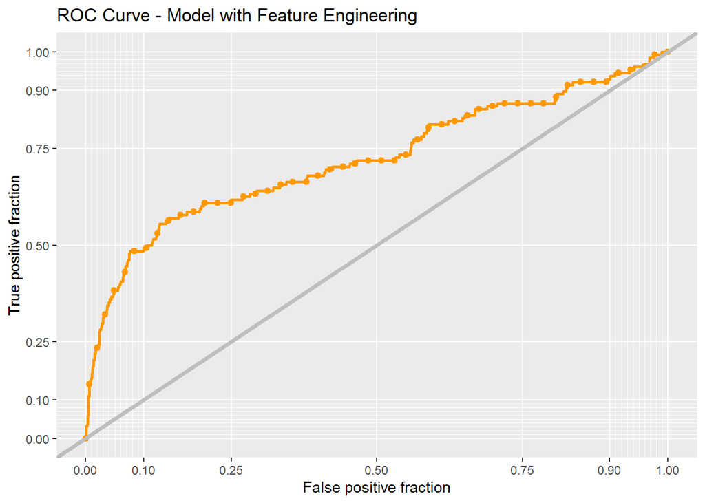

```r
ggplot(testProbs, aes(d = as.numeric(testProbs$Outcome), m = Probs)) +
  geom_roc(n.cuts = 50, labels = FALSE, colour = "#FE9900") +
  style_roc(theme = theme_grey) +
  geom_abline(slope = 1, intercept = 0, size = 1.5, color = 'grey') +
  labs(title = "ROC Curve - Model with Feature Engineering")
```

# Cost/Benefit Analysis

```r
## Cost benefit
cost_benefit_table <-
  testProbs %>%
  count(predOutcome, Outcome) %>%
  summarize(True_Negative = sum(n[predOutcome==0 & Outcome==0]),
            True_Positive = sum(n[predOutcome==1 & Outcome==1]),
            False_Negative = sum(n[predOutcome==0 & Outcome==1]),
            False_Positive = sum(n[predOutcome==1 & Outcome==0])) %>%
  gather(Variable, Count) %>%
  mutate(HCD_Expenditure =
           case_when(Variable == "True_Negative" ~ Count*0,
                Variable == "True_Positive" ~ (Count*2850)+(Count*5000),
                Variable == "False_Negative" ~ Count*0,
                Variable == "False_Positive" ~ (Count*2850))) %>%
  mutate(Home_Value_Added =
           case_when(Variable == "True_Negative" ~ Count*0,
                Variable == "True_Positive" ~ (Count*10000)+(Count*56000),
                Variable == "False_Negative" ~ Count*0,
                Variable == "False_Positive" ~ -(Count*0))) %>%
  mutate(Number_Credits =
           case_when(Variable == "True_Negative" ~ Count*0,
                     Variable == "True_Positive" ~ Count*1,
                     Variable == "False_Negative" ~ Count*0,
                     Variable == "False_Positive" ~ Count*0)) %>%
  bind_cols(data.frame(Description = c(
    "We correctly predicted not taking credit",
    "We correctly predicted taking credit",
    "We predicted would not take credit and customer took credit",
    "We predicted customer would take credit and customer did not take credit")))

kable(cost_benefit_table,
      caption = "Cost/Benefit Table") %>% kable_styling()
```

Cost/Benefit Table

[output not shown]

## Comparing Thresholds

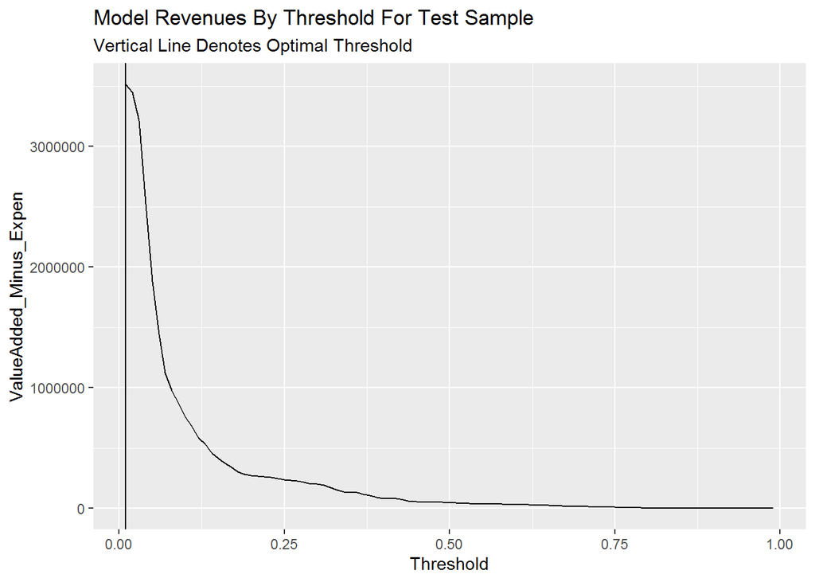

```r
## Optimise threshold
iterateThresholds <- function(data) {
  x = .01
  all_prediction <- data.frame()
  while (x <= 1) {

    this_prediction <-
      testProbs %>%
      mutate(predOutcome = ifelse(Probs > x, 1, 0)) %>%
      count(predOutcome, Outcome) %>%
      summarize(True_Negative = sum(n[predOutcome==0 & Outcome==0]),
                True_Positive = sum(n[predOutcome==1 & Outcome==1]),
                False_Negative = sum(n[predOutcome==0 & Outcome==1]),
                False_Positive = sum(n[predOutcome==1 & Outcome==0])) %>%
      gather(Variable, Count) %>%
      mutate(ValueAdded_Minus_Expen =
               if_else(Variable == "True_Negative", Count * 0,
               if_else(Variable == "True_Positive", (Count*1000)+(Count*56000)-(Count*2850)-(Count*5000),
               if_else(Variable == "False_Negative", Count*0,
               if_else(Variable == "False_Positive", Count*2850,0)))), Threshold = x) %>%
      mutate(Number_Credits=
               case_when(Variable == "True_Negative" ~ Count*0,
                         Variable == "True_Positive" ~ Count*.25,
                         Variable == "False_Negative" ~ Count*0,
                         Variable == "False_Positive" ~ Count*0))

    all_prediction <- rbind(all_prediction, this_prediction)
    x <- x + .01
  }
  return(all_prediction)
}

whichThreshold <- iterateThresholds(testProbs)

whichThreshold_revenue <-
  whichThreshold %>%
  group_by(Threshold) %>% na.omit() %>%
  summarize(ValueAdded_Minus_Expen = sum(ValueAdded_Minus_Expen))

ggplot(whichThreshold_revenue)+
  geom_line(aes(x = Threshold, y = ValueAdded_Minus_Expen))+
  geom_vline(xintercept =  pull(arrange(whichThreshold_revenue, -ValueAdded_Minus_Expen)[1,1]))+
  labs(title = "Model Revenues By Threshold For Test Sample",
       subtitle = "Vertical Line Denotes Optimal Threshold")
```

[figure not shown]

```r
whichThreshold_credits <-
  whichThreshold %>%
  group_by(Threshold) %>% na.omit() %>%
  summarize(Number_Credits= sum(Number_Credits))

ggplot(whichThreshold_credits)+
  geom_line(aes(x = Threshold, y = Number_Credits))+
  labs(title = "Model Number of Credits By Threshold For Test Sample",
       subtitle = "Vertical Line Denotes Optimal Threshold")
```

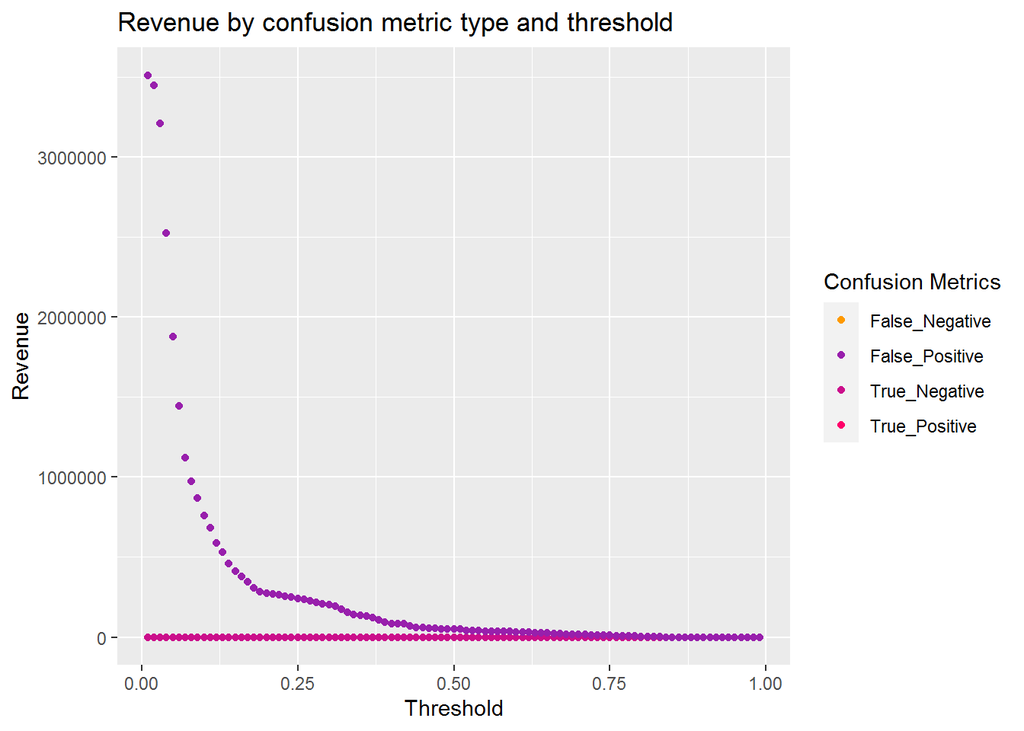

```r
## Plot confusion metrics for each threshold

whichThreshold %>%
  ggplot(.,aes(Threshold, ValueAdded_Minus_Expen, colour = Variable)) +
  geom_point() +
  scale_colour_manual(values = palette5[c(5, 1:3)]) +
  labs(title = "Revenue by confusion metric type and threshold",
       y = "Revenue") +
  #plotTheme() +
  guides(colour=guide_legend(title = "Confusion Metrics"))
```

```r
# Optimal Threshold
optimum_threshold <- pull(arrange(whichThreshold_revenue, -ValueAdded_Minus_Expen)[1,1])

opt <-
  whichThreshold %>%
  group_by(Threshold) %>%
  summarize(ValueAdded_Minus_Expen = sum(ValueAdded_Minus_Expen),
            Number_Credits= sum(Number_Credits)) %>%
  filter(Threshold == optimum_threshold)

fifty_thresh <-
  whichThreshold %>%
  group_by(Threshold) %>%
  summarize(ValueAdded_Minus_Expen = sum(ValueAdded_Minus_Expen),
            Number_Credits= sum(Number_Credits)) %>%
  filter(Threshold > .499 & Threshold < .51)

final <- data.frame(rbind(opt, fifty_thresh))

kable(final,
      caption = "Optimum Threshold and 50% Threshold") %>% kable_styling()
```

Optimum Threshold and 50% Threshold

[output not shown]

# Conclusion